# Use flowBasedClustering

## 4 - Clustering of typical days

Once we have the **vertices** and the **calendar**, the clustering algorithm can be run with the function `clusteringTypicalDays()`. The number of clusters of the different day categories (week days and week-end) can be set with `nbClustWeek` and `nbClustWeekend`. A report can be automaticcaly built using `report` and `reportPath` arguments.

```r
clusterTD <- clusteringTypicalDays(calendar, vertices, nbClustWeek = 3, nbClustWeekend = 1,
                              report = TRUE, reportPath = tempdir())
```

In case the clustering algorithm must be run on short periods of time or with more or less seasons or types of day. The function `clusterTypicalDaysForOneClass()` can be used instead of `clusteringTypicalDays()`.

```r
clusterTD <- clusterTypicalDaysForOneClass(vertices = vertices, dates = getSequence("2018-01-01", "2018-01-31"), nbCluster = 2,className = "january2018", reportPath = tempdir())
```

One can also use the output of `clusteringTypicalDays()` or `clusterTypicalDaysForOneClass()` to generate report later for one or more typical day(s) using `generateClusteringReport()`, or just plot domains with `clusterPlot()` :

```r
# build report for one typical day
generateClusteringReport(dayType = 7, data = clusterTD, outputFile = tempdir())
```

[figure not shown]

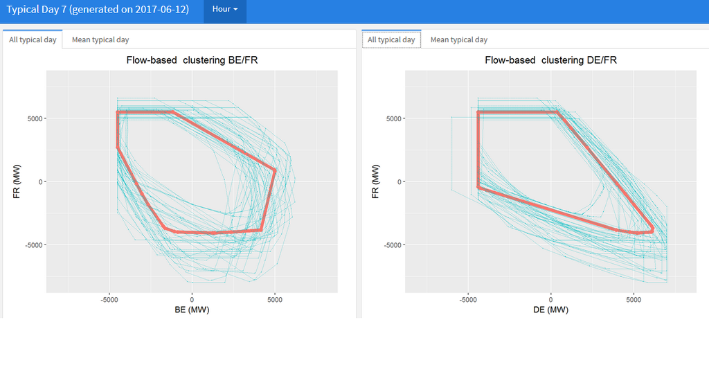

With `clusterPlot()`, one can choose 2 countries (`country1` & `country2`), the `hour` and the `dayType` (i.e. typical day identifer). In options, it can be decided whether to plot only the typical day (`typicalDayOnly`) or the full cluster and whether to use static or dynamic visualization (`ggplot`)

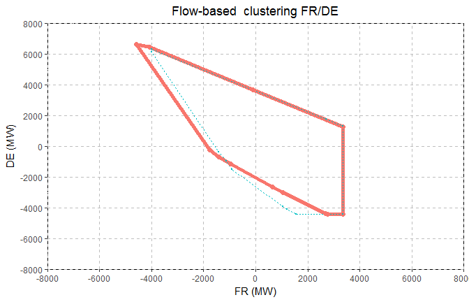

```r
# static graphic
clusterPlot(clusterTD, country1 = "FR", country2 = "DE",
            hour = 8, dayType = 9, typicalDayOnly = FALSE, ggplot = TRUE)
```

```r
# dynamic graphic
clusterPlot(clusterTD, country1 = "FR", country2 = "DE",
            hour = 8, dayType = 9, typicalDayOnly = TRUE, ggplot = FALSE)
```

## 5 - Probabilities and quantiles

Finally, the function `getProbability()` can be used to learn the correlations between the occurences of the different clusters and external data (typically climatic data).

- `climate` : data table, the first column is the `Date` (`YYYY-MM-DD`), other columns are exogenous variables (e.g. wind speed and temperature)
- `cluster` : output of `clusteringTypicalDays()` or `clusterTypicalDaysForOneClass()`

Below, an example of a climate file :

```
##          Date  FR_load   DE_wind    DE_solar
## 1: 2016-01-01 54071.88 0.1004866 0.018333333
## 2: 2016-01-02 56589.58 0.3691059 0.009583333
## 3: 2016-01-03 55517.71 0.3789791 0.014583333
## 4: 2016-01-04 64815.62 0.2645244 0.010000000
## 5: 2016-01-05 66279.69 0.1930778 0.012916667
## 6: 2016-01-06 67146.35 0.1458649 0.013333333
```

The quantiles are set with `levelsProba`, and can be :

- the same for all exogenous variables and classes using a `numeric vector`
- set for each class (season / type of day) and climate variable using a `named list`

```r
# same quantiles for each variables
MatProb <- getProbability(climate, clusterTD, levelsProba = c(1/3, 2/3))

# diffents quantiles for each class and variables
levelsProba <- list(summerWd = list(FR_load = c(0.5), DE_wind = c(1/3, 2/3), DE_solar = .5),
                    winterWD = list(FR_load = c(0.5, 0.7), DE_wind = c(.5)))
MatProb <- getProbability(climate, clusterTD, levelsProba = levelsProba)
```